# ToothGrowth

Michael Pearson

August 14, 2016

## Tooth Growth

The description of the data set “Tooth Growth”:

**The Effect of Vitamin C on Tooth Growth in Guinea Pigs**

Description

The response is the length of odontoblasts (cells responsible for tooth growth) in 60 guinea pigs. Each animal received one of three dose levels of vitamin C (0.5, 1, and 2 mg/day) by one of two delivery methods, (orange juice or ascorbic acid (a form of vitamin C and coded as VC).

Usage

ToothGrowth Format

A data frame with 60 observations on 3 variables.

[,1] len numeric Tooth length [,2] supp factor Supplement type (VC or OJ). [,3] dose numeric Dose in milligrams/day

## What to look for

Based on the description of the data, we want to see if there is a relationship between the lenght of the odontoblasts and the delivery method and the dosage of vitamin C. So our dependent variable is “len”, the length.

## Looking at delivery methods

Let’s make some plots of the data

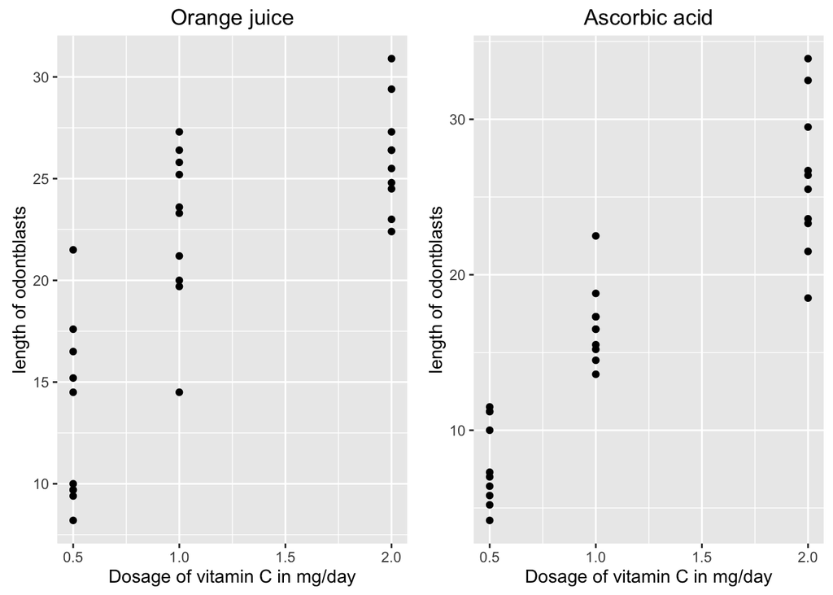

```r
 OJ <- data.frame(subset(ToothGrowth, supp == "OJ"))
 VC <- data.frame(subset(ToothGrowth, supp == "VC"))
 poj <- ggplot(OJ, aes(dose, len))
 poj <- poj + geom_point()
 poj <- poj +  xlab("Dosage of vitamin C in mg/day") +  ylab("length of odontblasts") + ggtitle("Orange juice")
 pvc <- ggplot(VC, aes(dose, len))
 pvc <- pvc + geom_point()
 pvc <- pvc + xlab("Dosage of vitamin C in mg/day") +  ylab("length of odontblasts") + ggtitle("Ascorbic acid")
 grid.arrange(poj, pvc, ncol = 2)
```

## Quick Conclusions

We can see that in both cases, an increase in dosage of vitamin C appears to increase the length of odontblasts.

## Looking at dosage

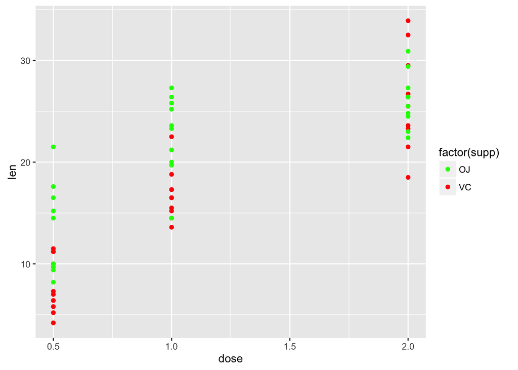

```r
allover <- ggplot(ToothGrowth, aes(dose, len, color=factor(supp)))
allover <- allover + geom_point() + scale_color_manual(values = c("green", "red"))
allover
```

```r
summary(ToothGrowth)
```

```
##       len        supp         dose
##  Min.   : 4.20   OJ:30   Min.   :0.500
##  1st Qu.:13.07   VC:30   1st Qu.:0.500
##  Median :19.25           Median :1.000
##  Mean   :18.81           Mean   :1.167
##  3rd Qu.:25.27           3rd Qu.:2.000
##  Max.   :33.90           Max.   :2.000
```

```r
p5 <- subset(ToothGrowth, ToothGrowth$dose == 0.5)
b5 <- t.test(len ~ supp, paired = FALSE, var.equal = TRUE, data = p5)
b5
```

```
##
##  Two Sample t-test
##
## data:  len by supp
## t = 3.1697, df = 18, p-value = 0.005304
## alternative hypothesis: true difference in means is not equal to 0
## 95 percent confidence interval:
##  1.770262 8.729738
## sample estimates:
## mean in group OJ mean in group VC
##            13.23             7.98
```

## Hypothesis testing

Here’s what we see when we compare the lenght of the odontoblasts at a dose of 0.5 mg/day

## For 0.5 mg/day

Based on the p-value of **0.0053037** we can reject the hypothesis that there is no difference in the growth of the odontoblasts at a dosage of **0.5 mg/day** when comparing the delivery method of **Orange Juice** compared to **Ascorbic Acid**. The odontoblasts are larger when the dose is given in Orange Juice.

```r
p10 <- subset(ToothGrowth, ToothGrowth$dose == 1.0)
b10 <- t.test(len ~ supp, paired = FALSE, var.equal = TRUE, data = p10)
b10
```

```
##
##  Two Sample t-test
##
## data:  len by supp
## t = 4.0328, df = 18, p-value = 0.0007807
## alternative hypothesis: true difference in means is not equal to 0
## 95 percent confidence interval:
##  2.840692 9.019308
## sample estimates:
## mean in group OJ mean in group VC
##            22.70            16.77
```

```r
p20 <- subset(ToothGrowth, ToothGrowth$dose == 2.0)
b20 <- t.test(len ~ supp, paired = FALSE, var.equal = TRUE, data = p20)
b20
```

```
##
##  Two Sample t-test
##
## data:  len by supp
## t = -0.046136, df = 18, p-value = 0.9637
## alternative hypothesis: true difference in means is not equal to 0
## 95 percent confidence interval:
##  -3.722999  3.562999
## sample estimates:
## mean in group OJ mean in group VC
##            26.06            26.14
```

## For 2.0 mg/day

Based on the p-value of **0.9637098** we must accept the hypothesis that there is no difference in the growth of the odontoblasts at a dosage of **2.0 mg/day** when comparing the delivery method of **Orange Juice** compared to **Ascorbic Acid**. There is no statistically meaningful difference in the size of the odontoblasts when the dosage is 2.0mg/day.